# Assignment 1

Ferrara Lorenzo, Lucchini Marco

## Description

|  | x | y | data |
| --- | --- | --- | --- |
| 1 | 10.39413323 | 70.11006 | 84 |
| 2 | 6.89985037 | 71.10941 | 84 |
| 3 | 1.90801770 | 68.11136 | 84 |
| 4 | -1.08708190 | 61.61559 | 84 |
| 5 | -2.08544844 | 54.62015 | 84 |
| 6 | -0.08871537 | 45.62600 | 84 |

|  | x | y | data |
| --- | --- | --- | --- |
| 1 | 98.57754 | 0.8906123 | 17.6 |
| 2 | 113.59737 | 19.5085930 | 27.1 |
| 3 | 110.53511 | 39.6851815 | 16.4 |
| 4 | 105.27965 | 28.3568305 | -9.5 |
| 5 | 95.20204 | 8.4319902 | 6.1 |
| 6 | 102.96788 | 53.0629008 | -0.5 |

### 1) Explore the requirement of stationary mean of the process. In case this requirement is not meet, detrend the data to ensure that the process is stationary in mean. Discuss the results and show the plot of the results

Firstly, we plot the locations.

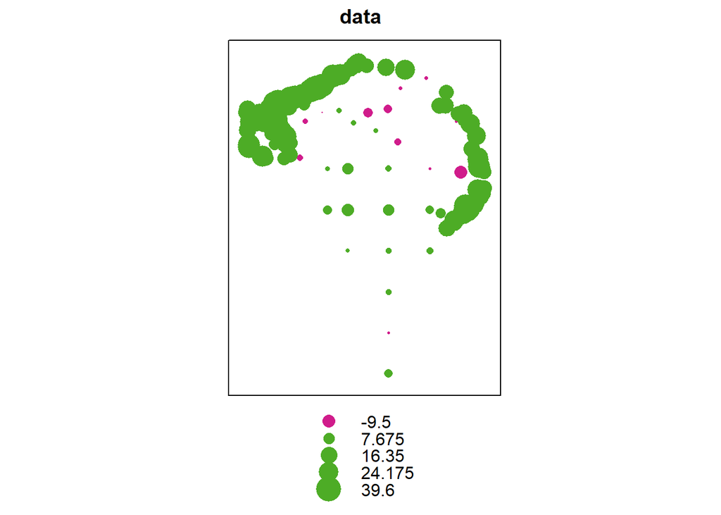

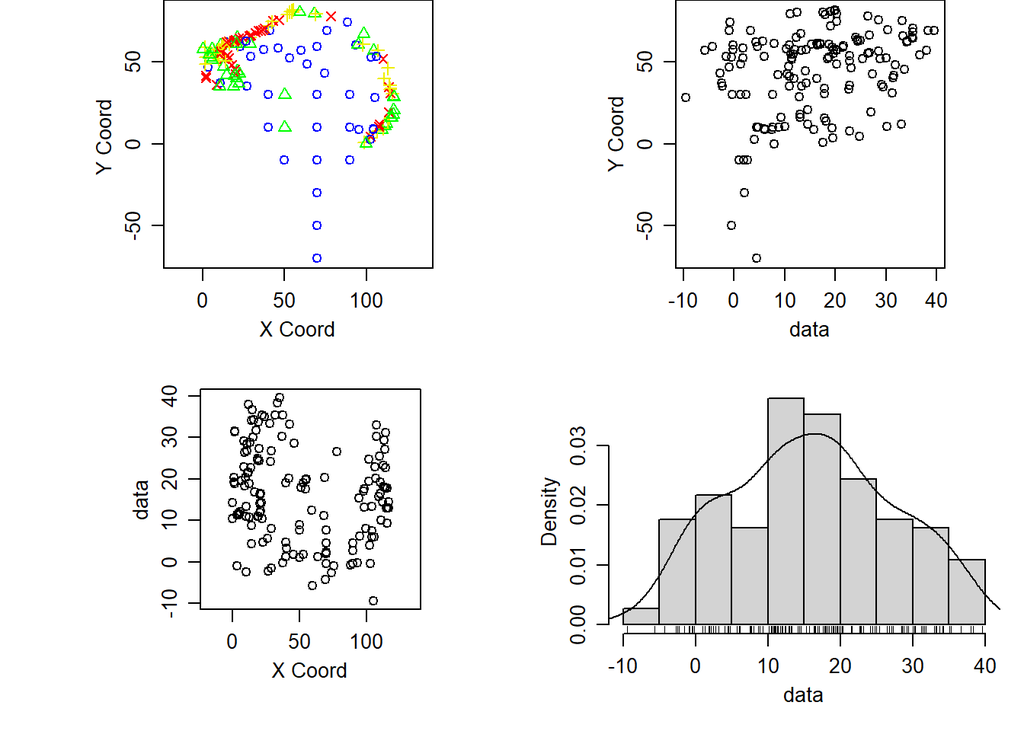

The process doesn’t seem stationary, indeed there is clearly a quadratic trend along the x direction. In addition we try using the y direction as regressor, to find a possible linear or quadratic trend.

```
##
## Call:
## lm(formula = data ~ x + y + I(x^2) + I(y^2), data = dataset)
##
## Residuals:
##     Min      1Q  Median      3Q     Max
## -22.639  -6.417  -0.964   6.024  22.744
##
## Coefficients:
##               Estimate Std. Error t value Pr(>|t|)
## (Intercept) 17.4502678  2.8429177   6.138 7.78e-09 ***
## x           -0.4938096  0.1103379  -4.475 1.55e-05 ***
## y            0.0349038  0.0570014   0.612    0.541
## I(x^2)       0.0040706  0.0009267   4.393 2.17e-05 ***
## I(y^2)       0.0019508  0.0008841   2.206    0.029 *
## ---
## Signif. codes:  0 '***' 0.001 '**' 0.01 '*' 0.05 '.' 0.1 ' ' 1
##
## Residual standard error: 10.19 on 143 degrees of freedom
## Multiple R-squared:  0.2026, Adjusted R-squared:  0.1803
## F-statistic: 9.082 on 4 and 143 DF,  p-value: 1.446e-06
```

The linear term in y doesn’t seem significant, so we remove it.

```
##
## Call:
## lm(formula = data ~ x + I(x^2) + I(y^2), data = dataset)
##
## Residuals:
##     Min      1Q  Median      3Q     Max
## -22.768  -6.656  -1.081   6.166  22.879
##
## Coefficients:
##               Estimate Std. Error t value Pr(>|t|)
## (Intercept) 18.3842839  2.3938539   7.680 2.23e-12 ***
## x           -0.5192823  0.1019735  -5.092 1.09e-06 ***
## I(x^2)       0.0042621  0.0008705   4.896 2.59e-06 ***
## I(y^2)       0.0023697  0.0005587   4.241 3.96e-05 ***
## ---
## Signif. codes:  0 '***' 0.001 '**' 0.01 '*' 0.05 '.' 0.1 ' ' 1
##
## Residual standard error: 10.17 on 144 degrees of freedom
## Multiple R-squared:  0.2005, Adjusted R-squared:  0.1838
## F-statistic: 12.04 on 3 and 144 DF,  p-value: 4.456e-07
```

Now we save the residuals of our linear model and look at the de-trended data.

|  | x | y | data | residuals |
| --- | --- | --- | --- | --- |
| 1 | 98.57754 | 0.8906123 | 17.6 | 8.987 |
| 2 | 113.59737 | 19.5085930 | 27.1 | 11.804 |
| 3 | 110.53511 | 39.6851815 | 16.4 | -0.391 |
| 4 | 105.27965 | 28.3568305 | -9.5 | -22.360 |
| 5 | 95.20204 | 8.4319902 | 6.1 | -1.645 |
| 6 | 102.96788 | 53.0629008 | -0.5 | -17.275 |

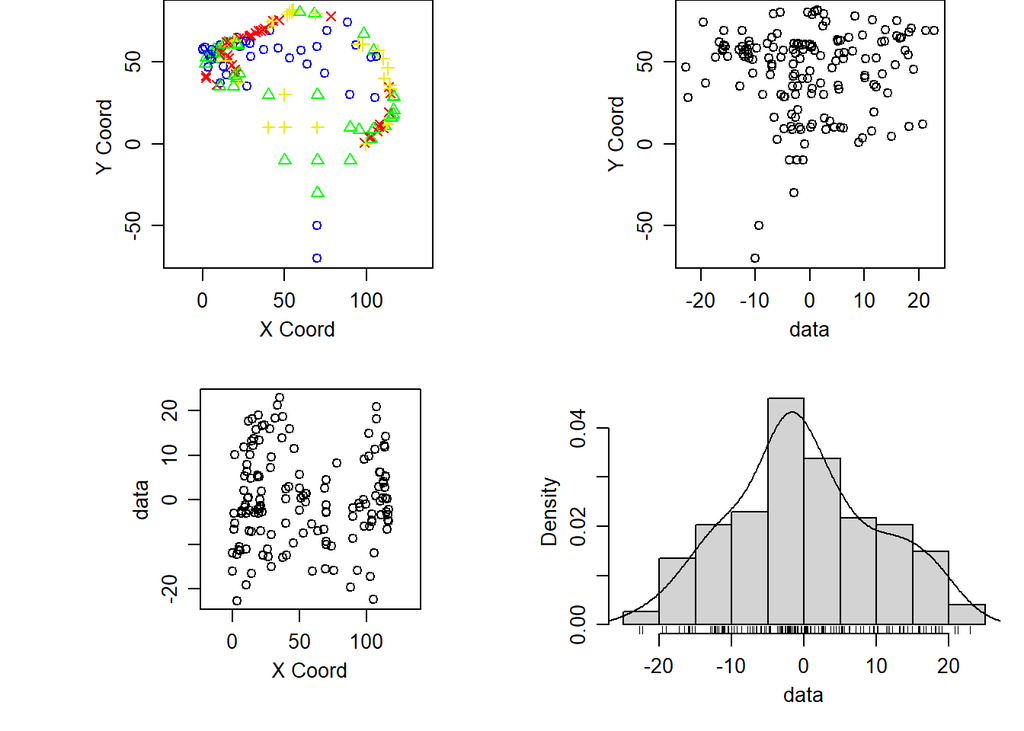

### 2) Explore the spatial dependence of the elevation variable using the variogram cloud and bins and the empirical variogram. Discuss the results and plot them